# Exploratory Analysis

# Chart 1

The purpose of including this chart is to promote visualization and conceptualization of whether or not there is correlation between the 5 highest/lowest state populations and reported investment on their youth. This scatterplot specifically highlights the socio-economic aspect of living costs in the US. From observation of this chart, there is a strong positive association between the variables state population and spending on kids. This chart revealed that in the year 2010, a couple of states which include New York, Illinois, and Georgia despite having lower populations have higher spendings amounts on their kids in comparison to some other states like Texas and Arizona.

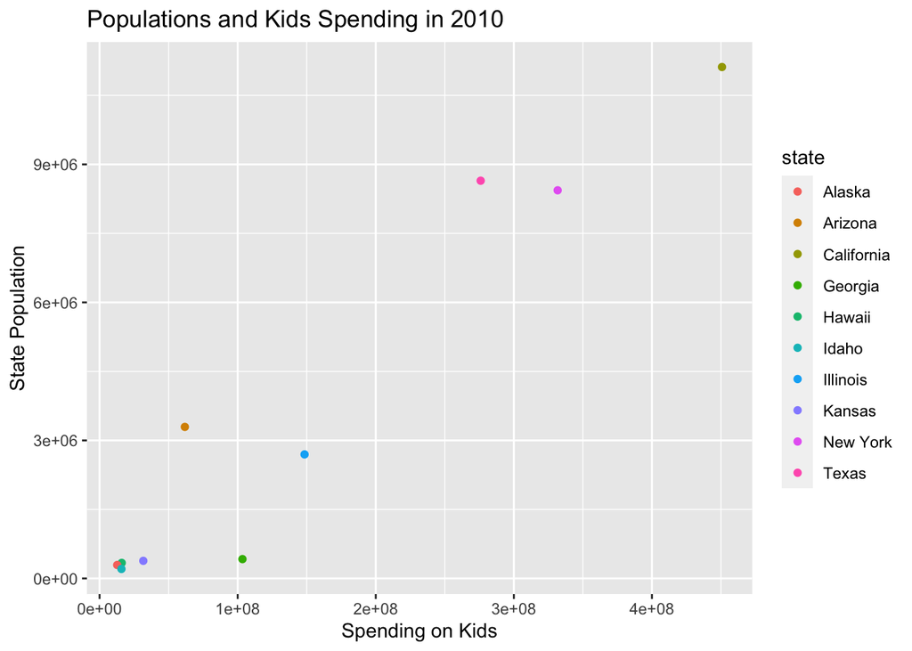

# Chart 2

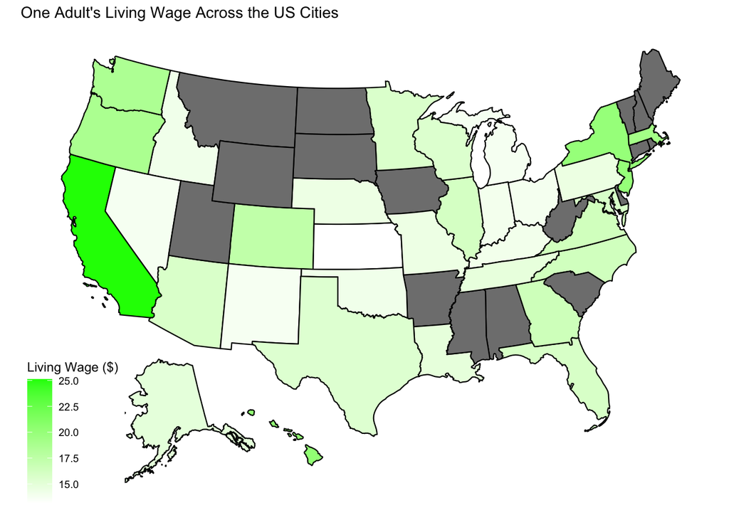

# Chart 3

The purpose of including this chart is to compare the living wage and minimum wage in 2020, in a select number of states. The chart clearly shows that the living wage for one adult with no kids is higher than the minimum wage in every state depicted in the graph. So, getting a minimum wage job would simply not be enough to reach the living wage, and gives one reason why poverty is so high in America.

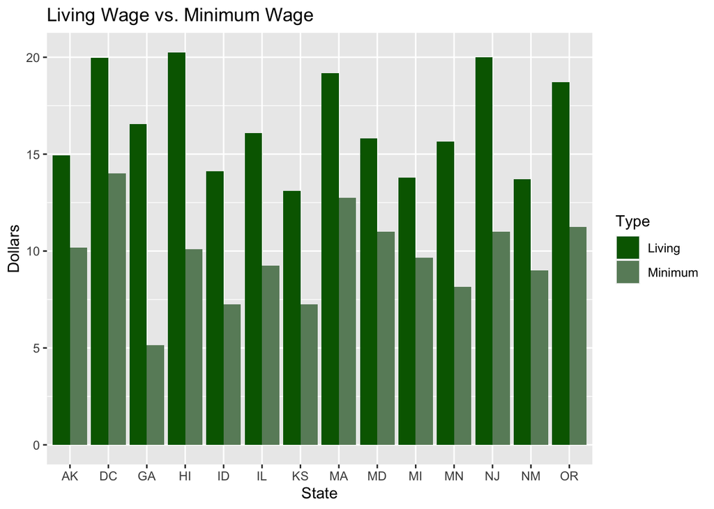